# α-Synuclein Aggregates in Parkinson’s Disease

SAA Analysis from PPMI Projects 155 & 237

Authors

Malaika Khiljee

Karolina Nordkamp

Isabella Christoffersen

Andreas Nielsen

Published

December 2, 2025

# Introduction

- Presynaptic neuronal protein α-Synuclein
- Aggregation between nerve cells -> inhibition of transmission
- 2 Projects using SAA (α-synuclein seed amplification assays)
- 24h versus 150h

**General focus:**

Does one of the methods perform better than the other, and which is one more efficient?

## Materials and Methods

**Materials:**

- PPMI (Parkinson’s Progression Markers Initiative) database
- 3 replicates of SAA (cerebrospinal fluid)
- Monitors the aggregation by measuring fluorescence intensity over time
- Sigmoidal curve: fmax, auc, ttt
- Set of critera for positive/negative/inconclusive

**Methods:**

- Tidyverse
- fmax values, means
- Patterns, distinction, t-test, standard deviation

## Tidying and augmenting

- Tidy data makes it much easier to handle. Requirements:
  - Each column is one variable (Not the case initially)
  - Each row is one observation
  - Each cell is one value

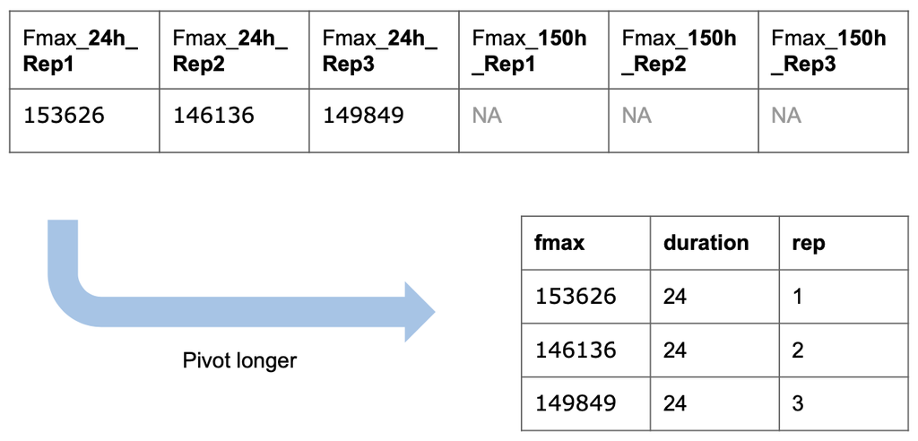

**Augmenting**

- Days from baseline: Calculated from rundates
- Mean of fmax for each visit
- Our own SAA_result

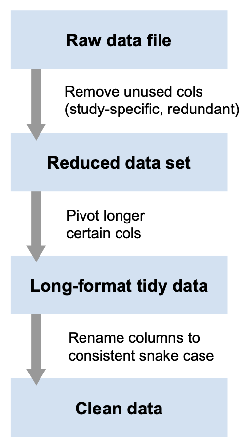

## Descriptive

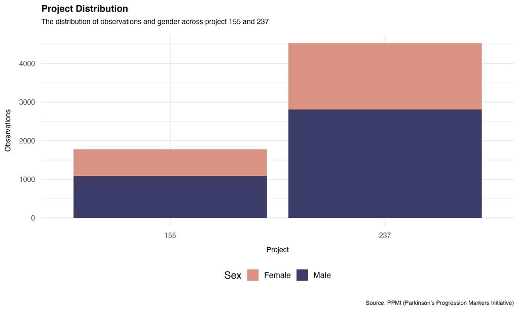

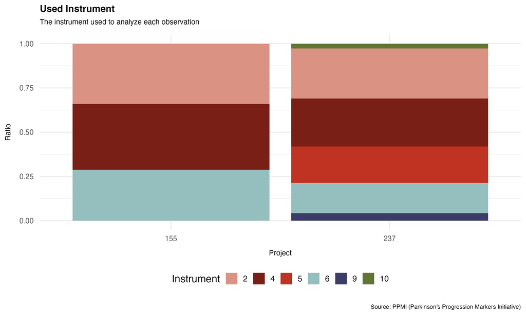

## SAA quality check

- SAA result and SAA custom quality check
- A non-mentioned criteria?
- Low fmax (200–600 RFU), huge, moderate
- Hard to know for sure

| **Result** | **Project 155** |
| --- | --- |
| Positive | All replicates Fmax ≥ 5,000 RFU |
| Negative | 0 or 1 replicate Fmax ≥ 5,000 RFU |
| Inconclusive | 2 replicates Fmax ≥ 5,000 RFU |

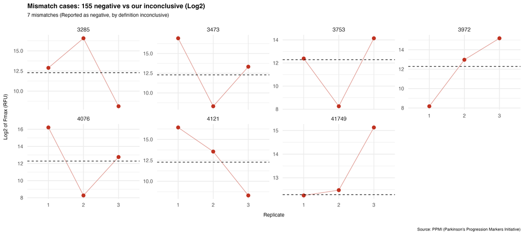

## SAA results

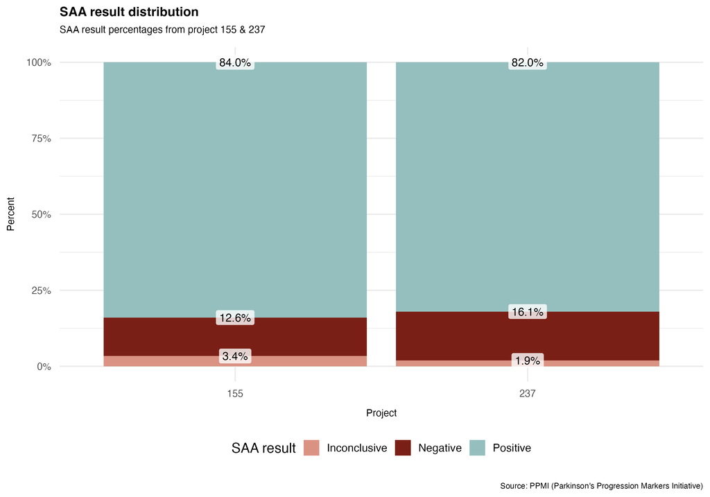

## Alternative diagnostic variables

- Fmax_mean
- Statistically significant difference in both 24h and 150h SAA
- AUC, SLOPE, T50 and TTT

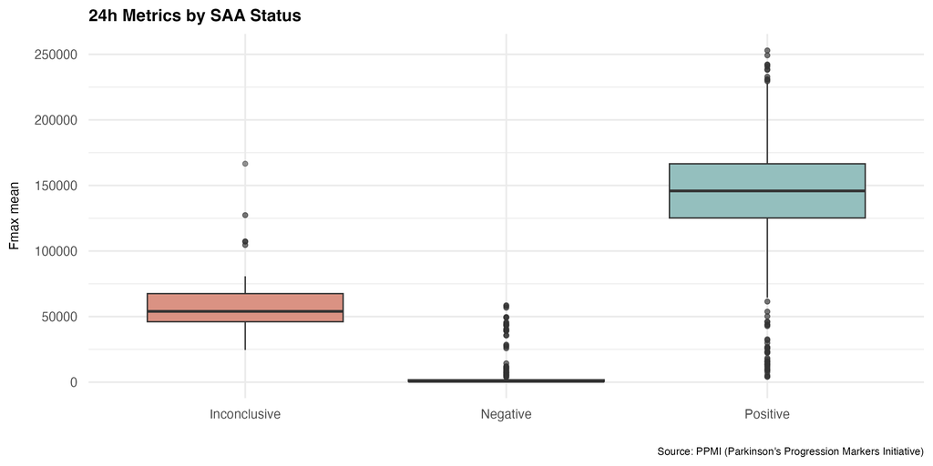

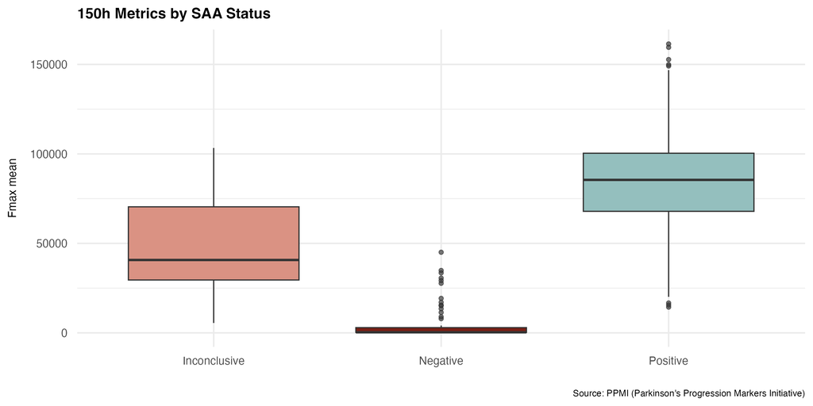

## Inconsistencies in the two projects (replicates)

**Fmax standard deviation**

- Can standard deviations in replicates say something about whether one project is better than the other?

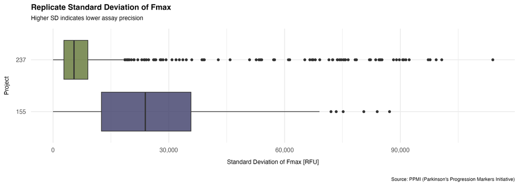

[output not shown]

**Instrument standard deviation**

- Can the instruments explain some of these differences?

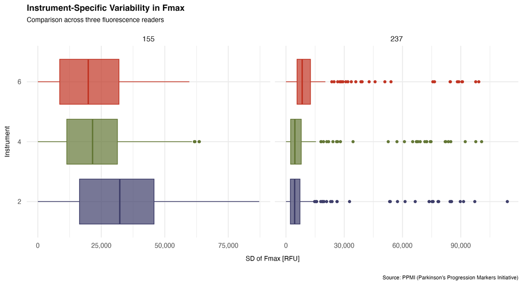

## Mean fmax over time

Question: Does the signal become stronger further into disease progression?

**Attempt at linear model**

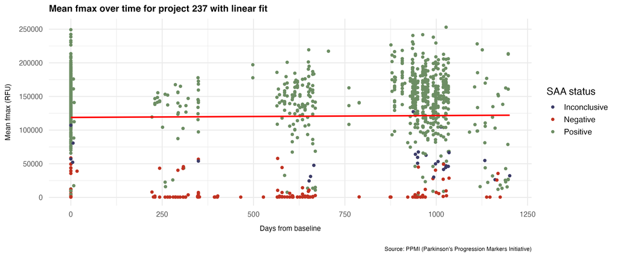

- Only for project 237 above
  - Not necessarily comparable fmax mean values
  - Project 155 only had close to baseline measurements
- No connection
- Note: Days from baseline is a not actually a measure of disease progression…

**Subset of patients**

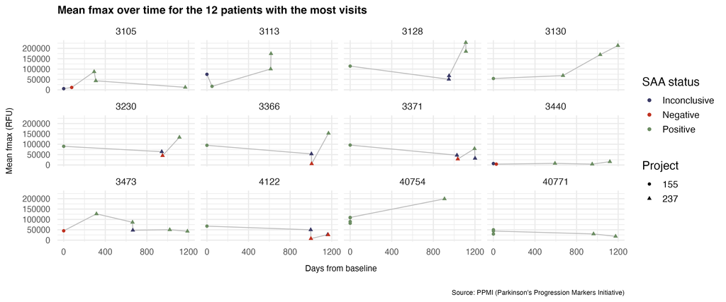

- Patient variation, if any connection at all
- We also looked at more patients

# Last notes/conclusions

**24-hour assay (237) vs 150-hour assay (155):**

Does one of the methods perform better than the other, and which is one more efficient?

- Project **237:** Fast, clear separation, consistent
- Healthy controls for better assessment